# LAScatalog formal class

A LAScatalog class is a representation in R of a file or a set of las files not loaded in memory. Indeed, a regular computer cannot load in R the entiere point cloud if it covers a wide area. For very hight density files it can even fail loading a single file (see also the “LAS formal class”" vignette). In lidR, to process dataset that cannot fits in memory we use a LAScatalog.

## Build a LAScatalog object reading a folder of las files

```r
ctg <- catalog("path/to/las/files/")
# or
ctg <- catalog("path/to/las/files/big_file.las")
```

```r
print(ctg)
```

[output not shown]

## Basic structure of a LAScatalog object

A LAScatalog inherits a SpatialPolygonsDataFrame. Thus, it has the structure of a SpatialPolygonsDataFrame plus some extra slots that stores information relative to how the LAScatalog will be processed.

The slot `data` of a LAScatalog object contains a `data.frame` with the most important information read from the header of .las or .laz files. Reading only the header of the file enable to have an overview of the content of the files very quickly without actually loading the point cloud. The columns of the table are named after the [LAS specification](http://www.asprs.org/wp-content/uploads/2010/12/LAS_1_4_r13.pdf) version 1.4

The other slots are well documented in the documentation ?`LAScatalog-class` and not described in this vignette.

## Allowed and non-allowed manipulation of a LAScatalog object

A LAScatalog is formally a SpatialPolygonsDataFrame but in the meantime its purpose is not to manipulate spatial data into R. The purpose of a LAScatalog is to represent a set of existing las/laz files. Thus a LAScatalog cannot be modified because it must be related to the actual content of the files. The following throw an error:

```r
ctg$Min.Z <- 0
```

```
#> Error in `$<-`(`*tmp*`, Min.Z, value = 0): LAScatalog data are read from standard files and cannot be modified
```

Obviously it is always possible to modify an R object by passing the simple restrictions. In that case the user will break something internally and a correct output is not guaranteed.

## Validation of LAScatalog object

It is common that users report bugs arising from the fact that the point cloud is invalid. This is why we introduced the function `lascheck` to perform an inspection of the LAScatalog objects. This function checks if a LAScatalog object is consistant (files are all of the same type for example). For example, it may happens that a catalog mixes files of type 1 with file of type 3 or files with different scale factors.

```r
lascheck(ctg)
```

```
#>
#>  Checking headers consistency
#>   - Checking file version consistency... ok
#>   - Checking scale consistency... ok
#>   - Checking offset consistency... ok
#>   - Checking point type consistency... ok
#>   - Checking VLR consistency... ok
#>   - Checking CRS consistency... ok
#>  Checking preprocessing already done
#>   - Checking negative outliers...
#>     warning: 2 file(s) with points below 0
#>   - Checking normalization... no
#>  Checking the geometry
#>   - Checking overlapping tiles...
#>     warning: Some tiles seem to overlap each other
```

The function `lascheck` when applied to a catalog does not perform a deep inspection of the point cloud unlike when applied to a LAS object. Indeed the point cloud is not actually read.

## Display a LAScatalog object

lidR provides a simple `plot` function to plot a LAScatalog object:

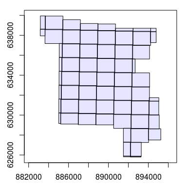

```r
plot(ctg)
```

The option `mapview = TRUE` displays the catalog on an interactive map with pan and zoom and enable to add a satellite map in background. It uses the package `mapview` internally. It is often useful to check if the CRS of the file are properly registered. The epsg code of the las file appears to be often inccorect according to our own experience.

```r
plot(ctg, mapview = TRUE, map.type = "Esri.WorldImagery")
```

[interactive chart not shown]

Being a SpatialPolygonsDataFrame the function `spplot` from `sp` can be used on a LAScatalog to check the content of the files. In the following we can immediatly see that the catalog is not normalized and is likely to contains outliers:

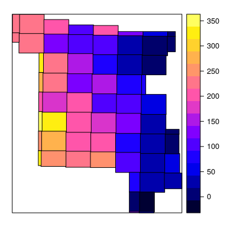

```r
spplot(ctg, "Min.Z")
```

## Apply lidR functions on a LAScatalog

Most of the function in lidR are compatible with a LAScatalog and works almost like with a point cloud loaded in memory. In the following example we use the function `grid_metrics` to compute the mean elevation of the points. The output is a continuous wall-to-wall RasterLayer. It works exactly like if the input was a LAS object.

```r
hmean <- grid_metrics(ctg, mean(Z), 20)
```

However usually processing a LAScatalog requieres to tune some processing options to get a better control on the computation. Indeed if the catalog is huge the output is likely to be huge as well and maybe the output cannot fits in R memory. For example `lasnormalize` throw an error if used ‘as is’ without tuning the processing options. Using `lasnormalize` like in the following example the expected `output` would be a huge point cloud loaded in memory. The lidR package forbids such call:

```r
output <- lasnormalize(ctg, tin())
```

```
#> Error in check_and_fix_options(ctg, need_buffer, check_alignment, need_output_file, : This function requires that the LAScatalog provides an output file template.
```

Instead one can use the processing option `opt_output_files`. Processing options drives how the big files are splitted in small chunks and how the outputs are either returned into R or written on disk into files.

```r
opt_output_file(ctg) <- "folder/where/to/store/outputs/{ORIGINALFILENAME}_normalized"
output <- lasnormalize(ctg, tin())
```

Here output is not a point cloud but a LAScatalog pointing to the new created files. User can check how the catalog will be process by calling `summary`

```r
summary(ctg)
```

```
#> class       : LAScatalog
#> extent      : 883166.1 , 895250.2 , 625793.6 , 639938.4 (xmin, xmax, ymin, ymax)
#> coord. ref. : +init=epsg:3005 +proj=aea +lat_1=50 +lat_2=58.5 +lat_0=45 +lon_0=-126 +x_0=1000000 +y_0=0 +datum=NAD83 +units=m +no_defs +ellps=GRS80 +towgs84=0,0,0
#> area        : 111.1 km²
#> points      : 0  points
#> density     : 0 points/m²
#> num. files  : 62
#> Summary of the processing options:
#>   - Catalog will be processed by file respecting the original tiling pattern
#>   - Catalog will be processed using 1 core(s).
#> Summary of the output options:
#>   - Outputs will be returned in R objects.
#> Summary of the input options:
#>   - readLAS will be called with the following select option: *
#>   - readLAS will be called with the following filter option:
```

Below some practical examples.

#### Example 1 - Raster

Load a catalog, process each file sequentially, return a RasterLayer into R.

```r
ctg <- catalog("path/to/las/files/")
hmean <- grid_metrics(ctg, mean(Z), 20)
```

#### Example 2 - Raster

Load a catalog, process each file sequentially. For each file writes a raster on disk named after the name of the processed files. Returns a lightweight virtual raster mosaic.

```r
ctg <- catalog("path/to/las/files/")
opt_output_files(ctg) <- "folder/where/to/store/outputs/dtm_{ORIGINALFILENAME}"
dtm <- grid_terrain(ctg, tin())
```

### Example 3 - Raster

Load a single big file too big to be actually loaded in memory. Process small chuncks of 100 x 100 meters at a time. Returns a RasterLayer into R.

```r
ctg <- catalog("path/to/las/files/bigfile.las")
opt_chunk_size(ctg) <- 100
chm <- grid_canopy(ctg, p2r())
```

### Example 4 - Tree detection

Load a catalog. Process 3 small chuncks of 200 x 200 meters at a time. Each chunk is loadded with an extra 20 m buffer. Returns a Shapefile into R.

```r
ctg <- catalog("path/to/las/files/")
opt_chunk_size(ctg) <- 200
opt_chunk_buffer(ctg) <- 20
opt_cores(ctg) <- 3
ttops <- tree_detection(ctg, lmf(5))
```

### Example 5 - Decimate

This is forbidden. The output would be too big.

```r
ctg <- catalog("path/to/las/files/")
decimated <- lasfilterdecimate(ctg, homogenize(4))
```

### Example 6 - Decimate

Load a catalog, process small chunks sequentially. For each chunks writes a laz file on disk named after the coordinates of the chunk. Returns a lightweight LAScatalog. Notice that the original catalog has been retiled.

```r
ctg <- catalog("path/to/las/files/")
opt_chunk_size(ctg) <- 100
opt_output_files(ctg) <- "folder/where/to/store/outputs/project_{XLEFT}_{YBOTTOM}_decimated"
opt_laz_compression(ctg) <- TRUE
decimated <- lasfilterdecimate(ctg, homogenize(4))
```

### Example 7 - Clip

Load a catalog. Load a shapefile of plot centers. Extract the plots and return a list of extracted plot in R.

```r
ctg <- catalog("path/to/las/files/")
shp <- shapefile("plot_center.shp")
plots <- lasclip(ctg, shp, radius = 11.2)
```

### Example 8 - Clip

Load a catalog. Load a shapefile of plot centers. Extract the plots and immediatly write them into a file named after the coordinates of the plot and an attribute of the sahpefile (here `FORESTTYPE` if such attribute exists in the shapefile). Returns a lightweight LAScatalog.

```r
ctg <- catalog("path/to/las/files/")
shp <- shapefile("plot_center.shp")
opt_output_files(ctg) <- "folder/where/to/store/outputs/plot_{XCENTER}_{YCENTER}_{FORESTTYPE}"
plots <- lasclip(ctg, plot_centers, radius = 11.2)
```